# RKC_Breast_Cancer

```python
import numpy as np
import pandas as pd

from sklearn.datasets import load_breast_cancer

data = load_breast_cancer()
X = data.data
y = data.target
feature_names = data.feature_names

df_X = pd.DataFrame(X, columns=feature_names)
df_y = pd.Series(y, name="target")

target_mapping = {0: "malignant", 1: "benign"}
df_y_label = df_y.map(target_mapping)

df = df_X.copy()
df["target"] = df_y
df["target_label"] = df_y_label

df.head()
```

|  | mean radius | mean texture | mean perimeter | mean area | mean smoothness | mean compactness | mean concavity | mean concave points | mean symmetry | mean fractal dimension | ... | worst perimeter | worst area | worst smoothness | worst compactness | worst concavity | worst concave points | worst symmetry | worst fractal dimension | target | target_label |
| --- | --- | --- | --- | --- | --- | --- | --- | --- | --- | --- | --- | --- | --- | --- | --- | --- | --- | --- | --- | --- | --- |
| 0 | 17.99 | 10.38 | 122.80 | 1001.0 | 0.11840 | 0.27760 | 0.3001 | 0.14710 | 0.2419 | 0.07871 | ... | 184.60 | 2019.0 | 0.1622 | 0.6656 | 0.7119 | 0.2654 | 0.4601 | 0.11890 | 0 | malignant |
| 1 | 20.57 | 17.77 | 132.90 | 1326.0 | 0.08474 | 0.07864 | 0.0869 | 0.07017 | 0.1812 | 0.05667 | ... | 158.80 | 1956.0 | 0.1238 | 0.1866 | 0.2416 | 0.1860 | 0.2750 | 0.08902 | 0 | malignant |
| 2 | 19.69 | 21.25 | 130.00 | 1203.0 | 0.10960 | 0.15990 | 0.1974 | 0.12790 | 0.2069 | 0.05999 | ... | 152.50 | 1709.0 | 0.1444 | 0.4245 | 0.4504 | 0.2430 | 0.3613 | 0.08758 | 0 | malignant |
| 3 | 11.42 | 20.38 | 77.58 | 386.1 | 0.14250 | 0.28390 | 0.2414 | 0.10520 | 0.2597 | 0.09744 | ... | 98.87 | 567.7 | 0.2098 | 0.8663 | 0.6869 | 0.2575 | 0.6638 | 0.17300 | 0 | malignant |
| 4 | 20.29 | 14.34 | 135.10 | 1297.0 | 0.10030 | 0.13280 | 0.1980 | 0.10430 | 0.1809 | 0.05883 | ... | 152.20 | 1575.0 | 0.1374 | 0.2050 | 0.4000 | 0.1625 | 0.2364 | 0.07678 | 0 | malignant |

5 rows × 32 columns

```python
df.info()
```

```
<class 'pandas.core.frame.DataFrame'>
RangeIndex: 569 entries, 0 to 568
Data columns (total 32 columns):
 #   Column                   Non-Null Count  Dtype
---  ------                   --------------  -----
 0   mean radius              569 non-null    float64
 1   mean texture             569 non-null    float64
 2   mean perimeter           569 non-null    float64
 3   mean area                569 non-null    float64
 4   mean smoothness          569 non-null    float64
 5   mean compactness         569 non-null    float64
 6   mean concavity           569 non-null    float64
 7   mean concave points      569 non-null    float64
 8   mean symmetry            569 non-null    float64
 9   mean fractal dimension   569 non-null    float64
```

[output cut: 24 more lines]

********************************************************************************************************************************  
In this project, the Breast Cancer Wisconsin dataset from the scikit-learn library was utilized. The dataset contains a total of 569 samples, each described by 30 numerical features related to cell nuclei characteristics extracted from digitized images of breast masses. The target variable represents a binary classification problem with two classes: 0 = malignant and 1 = benign.

### 2.1 - Missing value analysis

```python
missing_values = df.isnull().sum()
print(missing_values)
```

```
mean radius                0
mean texture               0
mean perimeter             0
mean area                  0
mean smoothness            0
mean compactness           0
mean concavity             0
mean concave points        0
mean symmetry              0
mean fractal dimension     0
radius error               0
texture error              0
perimeter error            0
area error                 0
smoothness error           0
compactness error          0
concavity error            0
concave points error       0
symmetry error             0
fractal dimension error    0
worst radius               0
worst texture              0
worst perimeter            0
worst area                 0
worst smoothness           0
worst compactness          0
worst concavity            0
worst concave points       0
worst symmetry             0
worst fractal dimension    0
target                     0
target_label               0
dtype: int64
```

******************************************************************************************************************************  
**The missing value analysis revealed that the dataset contains no missing values across any of its 30 features or the target variable. This indicates that no imputation is required at this stage.**  
******************************************************************************************************************************

### 2.2 - Outlier detection (IQR method)

```python
Q1 = df_X.quantile(0.25)
Q3 = df_X.quantile(0.75)
IQR = Q3 - Q1

outlier_mask = (df_X < (Q1 - 1.5 * IQR)) | (df_X > (Q3 + 1.5 * IQR))
outlier_counts = outlier_mask.sum()
print("Outliers:\n")
print(outlier_counts)
```

```
Outliers:

mean radius                14
mean texture                7
mean perimeter             13
mean area                  25
mean smoothness             6
mean compactness           16
mean concavity             18
mean concave points        10
mean symmetry              15
mean fractal dimension     15
radius error               38
texture error              20
perimeter error            38
area error                 65
smoothness error           30
compactness error          28
concavity error            22
concave points error       19
symmetry error             27
fractal dimension error    28
worst radius               17
worst texture               5
worst perimeter            15
worst area                 35
worst smoothness            7
worst compactness          16
worst concavity            12
worst concave points        0
worst symmetry             23
worst fractal dimension    24
dtype: int64
```

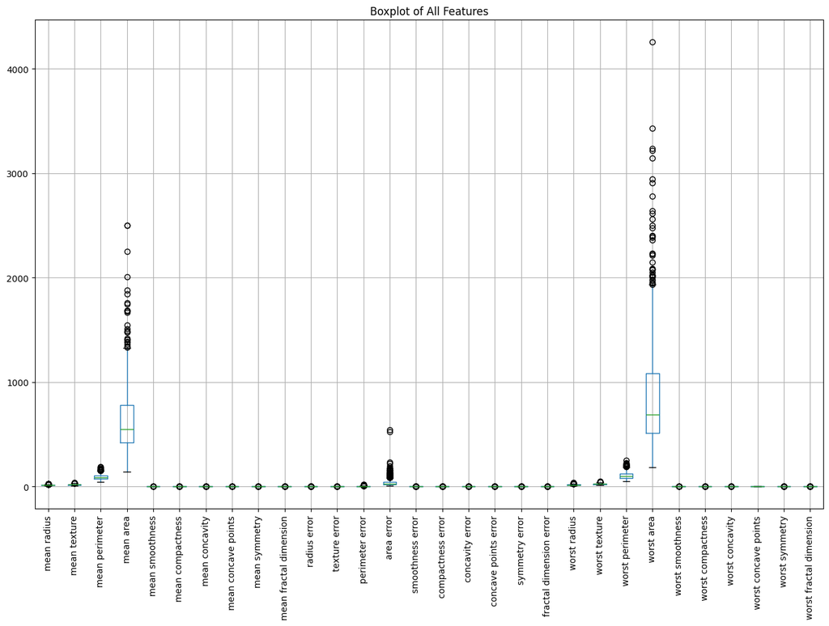

```python
import matplotlib.pyplot as plt
import seaborn as sns

plt.figure(figsize=(16, 10))
df_X.boxplot(rot=90)
plt.title("Boxplot of All Features")
plt.show()
```

```python
row_outlier_mask = outlier_mask.any(axis=1)

print("\nTotal number of rows:", df_X.shape[0])
print("Number of rows containing at least one outlier:", row_outlier_mask.sum())
```

```
Total number of rows: 569
Number of rows containing at least one outlier: 171
```

```python
df_X_clean = df_X[~row_outlier_mask].reset_index(drop=True)
df_y_clean = df_y[~row_outlier_mask].reset_index(drop=True)

print("\nShape of X before outlier removal:", df_X.shape)
print("Shape of X after outlier removal:", df_X_clean.shape)
```

```
Shape of X before outlier removal: (569, 30)
Shape of X after outlier removal: (398, 30)
```

```python
X = df_X_clean.values
y = df_y_clean.values

print("Final X shape:", X.shape)
print("Final y shape:", y.shape)
```

```
Final X shape: (398, 30)
Final y shape: (398,)
```

********************************************************************************************************************************  
Outlier analysis was conducted using both the Interquartile Range (IQR) method and boxplot visualizations. The IQR-based inspection demonstrated that almost every feature contains observations lying outside the 1.5 × IQR range, which are considered potential outliers. The boxplots provide a consistent visual confirmation of this pattern, revealing a substantial number of extreme values across the majority of variables.

To reduce the influence of these extreme observations on the learning process and improve the robustness of the subsequent MLP models, all instances that contained at least one outlier in any feature were removed from the dataset. After this filtering step, the remaining subset retains the overall structure of the data while exhibiting a more compact and stable distribution. This cleaned dataset (df_X_clean, df_y_clean) is used in the following stages of preprocessing, model training, and evaluation.  
********************************************************************************************************************************

### 2.3 - Datatype analysis

```python
print("Column dtypes:\n")
print(df_X_clean.dtypes)
```

```
Column dtypes:

mean radius                float64
mean texture               float64
mean perimeter             float64
mean area                  float64
mean smoothness            float64
mean compactness           float64
mean concavity             float64
mean concave points        float64
mean symmetry              float64
mean fractal dimension     float64
radius error               float64
texture error              float64
perimeter error            float64
area error                 float64
smoothness error           float64
compactness error          float64
concavity error            float64
concave points error       float64
symmetry error             float64
fractal dimension error    float64
worst radius               float64
worst texture              float64
worst perimeter            float64
worst area                 float64
worst smoothness           float64
worst compactness          float64
worst concavity            float64
worst concave points       float64
worst symmetry             float64
worst fractal dimension    float64
dtype: object
```

```python
numerical_cols = df_X_clean.select_dtypes(include=["float", "int"]).columns
categorical_cols = df_X_clean.select_dtypes(include=["object", "category"]).columns

print("\nNumerical feature count:", len(numerical_cols))
print("Categorical feature count:", len(categorical_cols))

print("\nNumerical columns:\n", list(numerical_cols))
print("\nCategorical columns:\n", list(categorical_cols))
```

```
Numerical feature count: 30
Categorical feature count: 0

Numerical columns:
 ['mean radius', 'mean texture', 'mean perimeter', 'mean area', 'mean smoothness', 'mean compactness', 'mean concavity', 'mean concave points', 'mean symmetry', 'mean fractal dimension', 'radius error', 'texture error', 'perimeter error', 'area error', 'smoothness error', 'compactness error', 'conca…

Categorical columns:
 []
```

******************************************************************************************************************************  
**The datatype analysis performed on the cleaned dataset (df_X_clean) shows that all predictor variables remain as continuous numerical features, while the target variable is a binary integer label. No categorical predictors are present, which eliminates the need for additional encoding steps.**  
******************************************************************************************************************************

### 3.1 - Statistical summary of features

```python
stats_df = pd.DataFrame({
    "mean": df_X_clean.mean(),
    "median": df_X_clean.median(),
    "std": df_X_clean.std(),
    "min": df_X_clean.min(),
    "max": df_X_clean.max(),
    "Q1": df_X_clean.quantile(0.25),
    "Q3": df_X_clean.quantile(0.75)
})

stats_df
```

|  | mean | median | std | min | max | Q1 | Q3 |
| --- | --- | --- | --- | --- | --- | --- | --- |
| mean radius | 13.376209 | 12.995000 | 2.484104 | 6.981000 | 20.590000 | 11.710000 | 14.640000 |
| mean texture | 18.505879 | 18.175000 | 3.911148 | 9.710000 | 29.810000 | 15.702500 | 20.755000 |
| mean perimeter | 86.403266 | 84.065000 | 16.841597 | 43.790000 | 137.800000 | 75.065000 | 94.730000 |
| mean area | 570.547990 | 518.300000 | 222.883241 | 143.500000 | 1320.000000 | 420.350000 | 664.200000 |
| mean smoothness | 0.093271 | 0.092385 | 0.012066 | 0.062510 | 0.125700 | 0.084520 | 0.101750 |
| mean compactness | 0.086260 | 0.079455 | 0.034979 | 0.019380 | 0.202200 | 0.059592 | 0.108975 |
| mean concavity | 0.060442 | 0.045580 | 0.049068 | 0.000000 | 0.254500 | 0.025628 | 0.083572 |
| mean concave points | 0.035902 | 0.028295 | 0.025625 | 0.000000 | 0.125900 | 0.018640 | 0.049478 |
| mean symmetry | 0.173639 | 0.172250 | 0.020819 | 0.116700 | 0.245900 | 0.159000 | 0.188500 |
| mean fractal dimension | 0.061211 | 0.060855 | 0.005015 | 0.049960 | 0.078180 | 0.057337 | 0.064213 |
| radius error | 0.306608 | 0.273450 | 0.127897 | 0.114400 | 0.747400 | 0.214225 | 0.371075 |
| texture error | 1.092313 | 1.032000 | 0.416156 | 0.360200 | 2.426000 | 0.782600 | 1.350000 |
| perimeter error | 2.153439 | 1.970000 | 0.892941 | 0.757000 | 5.216000 | 1.491500 | 2.594000 |
| area error | 26.512990 | 21.195000 | 15.553495 | 6.802000 | 83.500000 | 16.365000 | 31.307500 |
| smoothness error | 0.006390 | 0.006002 | 0.001995 | 0.002826 | 0.012150 | 0.004961 | 0.007507 |
| compactness error | 0.019689 | 0.017035 | 0.010626 | 0.002252 | 0.055920 | 0.011800 | 0.025057 |
| concavity error | 0.024014 | 0.020610 | 0.015108 | 0.000000 | 0.081580 | 0.013415 | 0.031753 |
| concave points error | 0.009910 | 0.009408 | 0.004037 | 0.000000 | 0.022580 | 0.006882 | 0.012600 |
| symmetry error | 0.018632 | 0.017920 | 0.005270 | 0.009539 | 0.035040 | 0.014650 | 0.021490 |
| fractal dimension error | 0.002998 | 0.002730 | 0.001306 | 0.000895 | 0.008015 | 0.002035 | 0.003691 |
| worst radius | 15.087623 | 14.395000 | 3.232713 | 7.930000 | 24.560000 | 13.015000 | 16.457500 |
| worst texture | 24.723015 | 24.585000 | 5.635779 | 12.020000 | 40.540000 | 20.385000 | 28.435000 |
| worst perimeter | 98.640477 | 93.905000 | 22.129399 | 50.410000 | 166.400000 | 83.922500 | 109.775000 |
| worst area | 728.471608 | 632.500000 | 329.649485 | 185.200000 | 1872.000000 | 516.025000 | 830.575000 |
| worst smoothness | 0.128684 | 0.128900 | 0.020253 | 0.081250 | 0.187800 | 0.113900 | 0.141775 |
| worst compactness | 0.211521 | 0.188300 | 0.107702 | 0.034320 | 0.611000 | 0.136100 | 0.265575 |
| worst concavity | 0.213448 | 0.181100 | 0.147218 | 0.000000 | 0.772700 | 0.104825 | 0.304350 |
| worst concave points | 0.096333 | 0.084985 | 0.049968 | 0.000000 | 0.254300 | 0.061492 | 0.128700 |
| worst symmetry | 0.279092 | 0.275750 | 0.043539 | 0.178300 | 0.412800 | 0.247725 | 0.307325 |
| worst fractal dimension | 0.079529 | 0.078030 | 0.012479 | 0.055210 | 0.120500 | 0.070195 | 0.086570 |

********************************************************************************************************************************  
The descriptive statistical analysis of the cleaned dataset provides a comprehensive overview of the central tendency and dispersion of the features. Most variables exhibit noticeable differences between their mean and median values, indicating slight skewness in their distributions. The standard deviation values suggest considerable variability across features, which is expected in biomedical measurements derived from imaging data.

The interquartile ranges (Q1–Q3) further confirm the presence of wide distribution spreads among many predictors. These statistical patterns emphasize the need for proper feature scaling prior to model training, particularly since MLP-based classifiers are sensitive to variations in feature magnitude.  
********************************************************************************************************************************

### 3.2 - Correlation matrix and heatmap

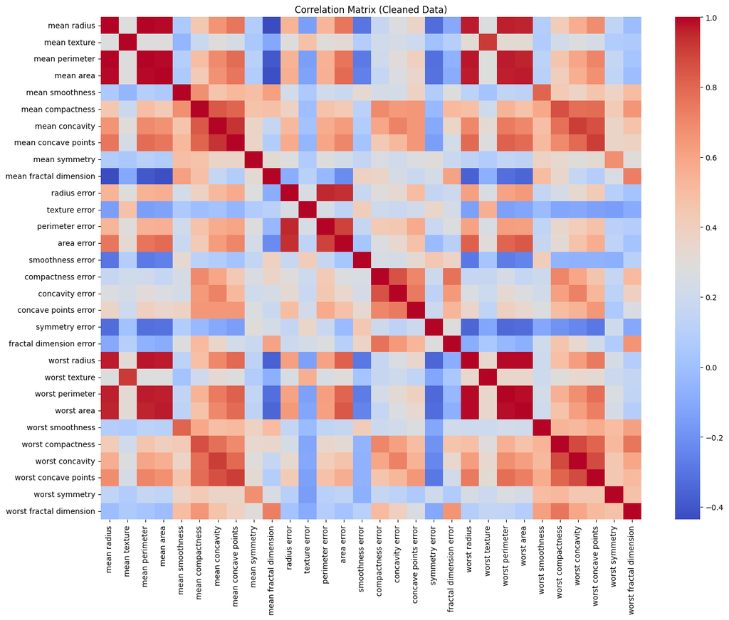

```python
corr_matrix = df_X_clean.corr()
plt.figure(figsize=(16, 12))
sns.heatmap(corr_matrix, cmap="coolwarm", annot=False)
plt.title("Correlation Matrix (Cleaned Data)")
plt.show()
```

```python
corr_unstack = corr_matrix.where(np.triu(np.ones(corr_matrix.shape), k=1).astype(bool))
corr_series = corr_unstack.stack().sort_values(ascending=False)
top3_corr = corr_series.head(3)
print("Top 3 Most Highly Correlated Feature Pairs:\n")
print(top3_corr)
```

```
Top 3 Most Highly Correlated Feature Pairs:

mean radius   mean perimeter     0.998113
worst radius  worst perimeter    0.992543
mean radius   mean area          0.992047
dtype: float64
```

********************************************************************************************************************************  
The Pearson correlation matrix revealed several strong linear relationships among the features. After removing redundant correlations and sorting the upper-triangular coefficients, the three strongest feature pairs were identified. These relationships indicate substantial multicollinearity within the dataset, which is typical for morphological measurements derived from medical imaging.

The top three highest correlations obtained from the dataset are: • mean radius – mean perimeter (r = 0.998): Both measurements capture overall nucleus size, with perimeter increasing proportionally to radius. Their nearly perfect correlation reflects direct geometric dependence.

• worst radius – worst perimeter (r = 0.9925): The “worst” metrics represent the most extreme values among segmented nuclei. Their strong correlation again reflects shared geometric scaling, confirming that the largest nuclei in each sample exhibit consistent size–perimeter proportionality.

• mean radius – mean area (r = 0.9920): Area is mathematically related to radius through the squared relationship. Thus, it is expected that larger nuclei (higher radius) correspond to significantly higher area values, explaining the very high correlation.

These strong correlations demonstrate that many geometric features of the cell nuclei are tightly interconnected. While multicollinearity does not negatively affect neural network–based classifiers such as MLPs, understanding these relationships provides important insight into the biological structure of tumor morphology.  
********************************************************************************************************************************

### 3.3 - Boxplot

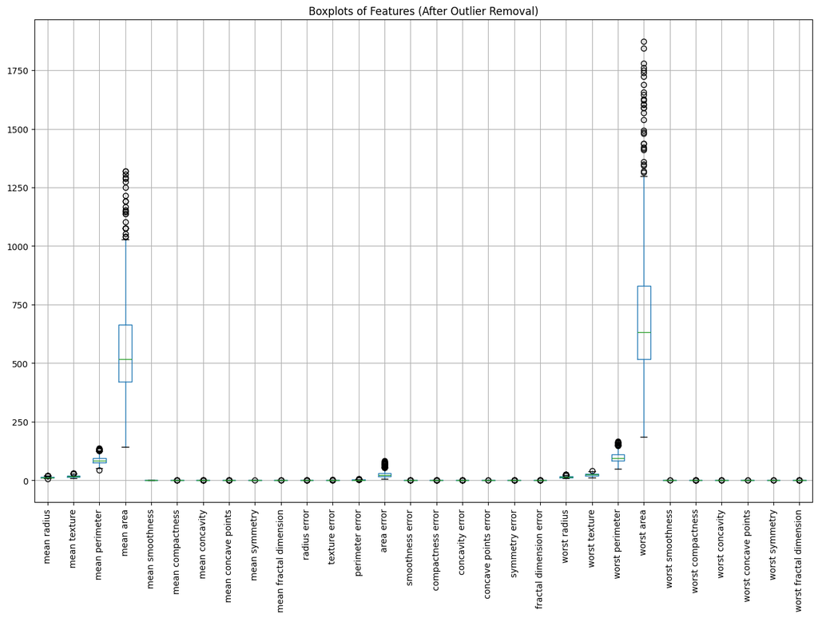

```python
plt.figure(figsize=(16, 10))
df_X_clean.boxplot(rot=90)
plt.title("Boxplots of Features (After Outlier Removal)")
plt.show()
```

********************************************************************************************************************************  
The boxplots generated after removing outliers using the IQR method indicate that the overall distribution of the features has become noticeably more compact compared to the original dataset. While this process successfully eliminated a substantial portion of extreme observations, it is evident that several features still contain residual outliers.

The presence of these remaining outlier values is not unexpected. Biomedical measurements—particularly those derived from tumor morphology—naturally exhibit biological variability and occasionally extreme deviations due to differences in tissue structure, sampling conditions, and patient-specific factors. Although such residual outliers may still pose a potential challenge for certain machine learning models, they represent an inherent characteristic of the dataset rather than noise to be completely removed.

Importantly, the IQR filtering allowed the dataset to retain its essential biological diversity while removing the most problematic extreme values. This results in a cleaner yet still representative dataset that balances statistical robustness with biological realism. Consequently, the dataset is now better prepared for subsequent preprocessing and model training stages, especially once appropriate scaling is applied.  
********************************************************************************************************************************

### 4 - Scaling

******************************************************************************************************************************  
**Since the majority of extreme values were removed through IQR outlier filtering, the feature distributions became sufficiently compact for z-score normalization. StandardScaler ensures stable gradient-based optimization during MLP training and is widely recommended in the literature for neural network models. MinMaxScaler was avoided due to its sensitivity to outliers, and RobustScaler was deemed unnecessary after outlier removal.**  
******************************************************************************************************************************

```python
from sklearn.preprocessing import StandardScaler

scaler = StandardScaler()
X_scaled = scaler.fit_transform(df_X_clean)

X_scaled_df = pd.DataFrame(X_scaled, columns=df_X_clean.columns)
X_scaled_df.head()
```

|  | mean radius | mean texture | mean perimeter | mean area | mean smoothness | mean compactness | mean concavity | mean concave points | mean symmetry | mean fractal dimension | ... | worst radius | worst texture | worst perimeter | worst area | worst smoothness | worst compactness | worst concavity | worst concave points | worst symmetry | worst fractal dimension |
| --- | --- | --- | --- | --- | --- | --- | --- | --- | --- | --- | --- | --- | --- | --- | --- | --- | --- | --- | --- | --- | --- |
| 0 | 1.964461 | 0.377377 | 1.973596 | 2.108920 | 0.112751 | 0.650915 | 1.066356 | 1.488638 | 0.277054 | -0.756789 | ... | 2.413510 | 0.521788 | 2.468580 | 2.665355 | 0.767070 | 0.428375 | 1.121869 | 1.941020 | 0.625692 | 0.333092 |
| 1 | 0.134540 | 0.594978 | 0.225722 | 0.033027 | 2.126689 | 2.239566 | 0.677832 | 0.935739 | 2.210386 | 2.655183 | ... | 0.610898 | 0.607065 | 0.541116 | 0.511879 | 1.815139 | 1.456575 | 0.369659 | 1.187592 | 0.931552 | 2.854076 |
| 2 | 1.065623 | 1.211941 | 0.968866 | 1.020884 | -0.930314 | -0.560180 | -0.560181 | -0.104415 | -1.002217 | -0.846630 | ... | 1.270617 | 1.626840 | 1.138359 | 1.280326 | -0.523241 | -0.524523 | -0.459405 | 0.068471 | 0.361226 | 0.400490 |
| 3 | 0.968887 | -0.157666 | 1.022372 | 0.945414 | 0.317713 | 1.229127 | 0.797817 | 1.178389 | 0.507899 | -0.077988 | ... | 1.651581 | 0.454277 | 1.712978 | 1.732891 | 0.539659 | 3.248023 | 1.244971 | 1.696556 | 2.302172 | 2.027655 |
| 4 | 0.997102 | 1.393701 | 1.028317 | 0.953051 | -0.768502 | 0.399021 | 0.794553 | 0.693088 | 0.531946 | -1.563363 | ... | 0.542758 | 0.521788 | 0.604460 | 0.449613 | -0.770426 | -0.177761 | 0.127537 | 0.311933 | 0.041568 | -1.336598 |

5 rows × 30 columns

********************************************************************************************************************************  
StandardScaler was applied to all features in the cleaned dataset, transforming each variable to have zero mean and unit variance. This choice is particularly appropriate for MLP models, which rely on gradient-based optimization methods and therefore benefit from standardized feature distributions.

Since the dataset had already undergone outlier removal through IQR filtering, z-score normalization produced a stable and balanced scaling behavior without being disproportionately influenced by extreme values. The resulting scaled dataset (X_scaled) is now well suited for training neural network classifiers with improved convergence and numerical stability.  
********************************************************************************************************************************

### 5 – Train / Validation / Test Split

```python
X = X_scaled
y_clean = df_y_clean.values

print("X samples:", X.shape[0])
print("y_clean samples:", len(y_clean))
```

```
X samples: 398
y_clean samples: 398
```

```python
from sklearn.model_selection import train_test_split

X_train, X_temp, y_train, y_temp = train_test_split(X, y_clean, test_size=0.30, random_state=42, stratify=y)

X_val, X_test, y_val, y_test = train_test_split(X_temp, y_temp, test_size=2/3, random_state=42, stratify=y_temp)

print("Train set shape:", X_train.shape)
print("Validation set shape:", X_val.shape)
print("Test set shape:", X_test.shape)
```

```
Train set shape: (278, 30)
Validation set shape: (40, 30)
Test set shape: (80, 30)
```

******************************************************************************************************************************  
**The dataset was partitioned into training, validation, and test subsets following a 70%–10%–20% ratio using a two-stage stratified splitting procedure. Stratification was applied to preserve the original class distribution within each subset, ensuring reliable model training and evaluation for this binary classification problem.**  
******************************************************************************************************************************

### 6.1 - Construction of Multiple MLP Models

```python
from sklearn.neural_network import MLPClassifier

# Model 1 – Simple architecture
mlp1 = MLPClassifier(
    hidden_layer_sizes=(16,),
    activation="relu",
    learning_rate_init=0.001,
    max_iter=1000,
    early_stopping=True,
    random_state=42
)

# Model 2 – Medium-sized architecture
mlp2 = MLPClassifier(
    hidden_layer_sizes=(32, 16),
    activation="relu",
    learning_rate_init=0.005,
    max_iter=1000,
    early_stopping=True,
    random_state=42
)

# Model 3 – Wide architecture
mlp3 = MLPClassifier(
    hidden_layer_sizes=(64, 64),
    activation="tanh",
    learning_rate_init=0.001,
    max_iter=1000,
    early_stopping=True,
    random_state=42
)

# Model 4 – Deep architecture
mlp4 = MLPClassifier(
    hidden_layer_sizes=(128, 64, 32),
    activation="relu",
    learning_rate_init=0.0005,
    max_iter=1000,
    early_stopping=True,
    random_state=42
)

# Model 5 – Low learning rate
mlp5 = MLPClassifier(
    hidden_layer_sizes=(32,),
    activation="relu",
    learning_rate_init=0.0001,
    max_iter=1000,
    early_stopping=True,
    random_state=42
)

# Dictionary for easier iteration over models
models = {
    "Model 1 - Simple": mlp1,
    "Model 2 - Medium": mlp2,
    "Model 3 - Wide": mlp3,
    "Model 4 - Deep": mlp4,
    "Model 5 - Low LR": mlp5
}
```

### 6.2 - Training All Models on the Training Set

```python
for name, model in models.items():
    print(f"Training {name}...")
    model.fit(X_train, y_train)

print("All models have been successfully trained.")
```

```
Training Model 1 - Simple...
Training Model 2 - Medium...
Training Model 3 - Wide...
Training Model 4 - Deep...
Training Model 5 - Low LR...
All models have been successfully trained.
```

********************************************************************************************************************************  
Five multilayer perceptron (MLP) architectures were implemented to examine how different network configurations affect classification performance. The models vary in depth (1 to 3 hidden layers), width (16 to 128 neurons per layer), activation functions, and learning rate parameters.

Each model was trained on the standardized training subset using a fixed random seed to ensure reproducibility. This structured approach enables a controlled comparison of architectural complexity and optimization behavior.

During initial training, some MLP models raised a ConvergenceWarning, indicating that the optimizer reached the maximum iteration limit before fully converging. To address this, the training procedure was updated by increasing the max_iter parameter and enabling early_stopping where appropriate. After incorporating these adjustments, the models converged properly without further warnings, ensuring stable and reliable optimization across all architectures.

********************************************************************************************************************************

### 7 - Evaluation of Validation Performance

```python
from sklearn.metrics import accuracy_score, precision_score, recall_score, f1_score, roc_auc_score

results = []

for name, model in models.items():
    y_pred = model.predict(X_val)
    y_prob = model.predict_proba(X_val)[:, 1]  # needed for AUC

    accuracy = accuracy_score(y_val, y_pred)
    precision = precision_score(y_val, y_pred)
    recall = recall_score(y_val, y_pred)
    f1 = f1_score(y_val, y_pred)
    auc = roc_auc_score(y_val, y_prob)

    results.append([name, accuracy, precision, recall, f1, auc])

# Create DataFrame
results_df = pd.DataFrame(results, columns=[
    "Model", "Accuracy", "Precision", "Recall", "F1-Score", "ROC-AUC"
])

results_df
```

|  | Model | Accuracy | Precision | Recall | F1-Score | ROC-AUC |
| --- | --- | --- | --- | --- | --- | --- |
| 0 | Model 1 - Simple | 0.900 | 0.882353 | 1.000000 | 0.937500 | 0.950000 |
| 1 | Model 2 - Medium | 0.950 | 1.000000 | 0.933333 | 0.965517 | 0.996667 |
| 2 | Model 3 - Wide | 0.925 | 0.965517 | 0.933333 | 0.949153 | 0.990000 |
| 3 | Model 4 - Deep | 0.975 | 0.967742 | 1.000000 | 0.983607 | 0.996667 |
| 4 | Model 5 - Low LR | 0.725 | 0.743590 | 0.966667 | 0.840580 | 0.086667 |

********************************************************************************************************************************

The validation results reveal substantial performance differences among the five MLP architectures, demonstrating the importance of network depth, width, and learning rate selection.

Model 3 (Wide) performed similarly well, with accuracy = 92.5% and a strong AUC of 0.99. Although slightly weaker than Model 2, it still provides a high-quality boundary and benefits from expanded representational capacity.

Model 4 (Deep) delivered the best overall performance. It achieved the highest accuracy (97.5%), perfect recall (1.00), and an outstanding F1-score (0.9836). Its ROC-AUC of 0.9967, tied with Model 2, reflects excellent class separability. This indicates that deeper architectures are particularly effective for capturing complex nonlinear relationships within the dataset.

********************************************************************************************************************************

### 8 - Evaluation of the Best Model on the Test Set

#### Selected Model: Model 4 – Deep (128, 64, 32)

### 8.1 - Performance Metrics

```python
best_model = models["Model 4 - Deep"]

# Predictions
y_test_pred = best_model.predict(X_test)
y_test_prob = best_model.predict_proba(X_test)[:, 1]

# Compute metrics
test_accuracy = accuracy_score(y_test, y_test_pred)
test_precision = precision_score(y_test, y_test_pred)
test_recall = recall_score(y_test, y_test_pred)
test_f1 = f1_score(y_test, y_test_pred)
test_auc = roc_auc_score(y_test, y_test_prob)

print("Test Accuracy:", test_accuracy)
print("Test Precision:", test_precision)
print("Test Recall:", test_recall)
print("Test F1-Score:", test_f1)
print("Test ROC-AUC:", test_auc)
```

```
Test Accuracy: 0.9125
Test Precision: 0.9491525423728814
Test Recall: 0.9333333333333333
Test F1-Score: 0.9411764705882353
Test ROC-AUC: 0.9483333333333334
```

********************************************************************************************************************************

The performance of the best MLP model (Model 4) decreased when evaluated on the independent test set. This is an expected outcome, as the validation set was substantially smaller (n=40) and may have contained samples that were easier to classify, resulting in slightly inflated validation metrics.

In contrast, the test set (n=80) provides a more reliable and unbiased estimate of generalization performance. The deep MLP architecture is also more prone to partially fitting patterns specific to the validation split, which further explains the drop in accuracy, F1-score, and ROC-AUC. Despite this reduction, the test-set metrics remain strong and demonstrate robust real-world performance.

********************************************************************************************************************************

### 8.2 - Confusion Matrix (Heatmap)

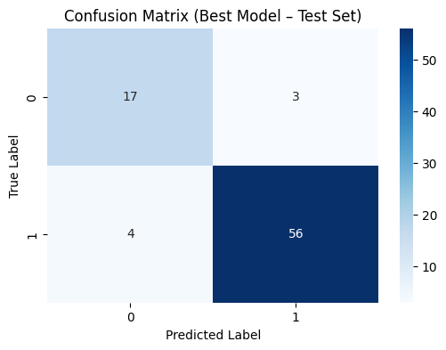

```python
from sklearn.metrics import confusion_matrix
cm = confusion_matrix(y_test, y_test_pred)

plt.figure(figsize=(6,4))
sns.heatmap(cm, annot=True, fmt='d', cmap='Blues')
plt.title("Confusion Matrix (Best Model – Test Set)")
plt.xlabel("Predicted Label")
plt.ylabel("True Label")
plt.show()
```

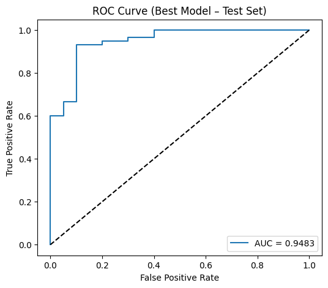

```python
from sklearn.metrics import roc_curve

fpr, tpr, thresholds = roc_curve(y_test, y_test_prob)

plt.figure(figsize=(6,5))
plt.plot(fpr, tpr, label=f"AUC = {test_auc:.4f}")
plt.plot([0,1], [0,1], 'k--')  # diagonal
plt.title("ROC Curve (Best Model – Test Set)")
plt.xlabel("False Positive Rate")
plt.ylabel("True Positive Rate")
plt.legend()
plt.show()
```

********************************************************************************************************************************

The deep MLP architecture (128–64–32), previously identified as the best-performing model on the validation set, was evaluated on the independent test set to obtain an unbiased estimate of its generalization ability. The model achieved 91.25% accuracy, 0.949 precision, 0.933 recall, and an F1-score of 0.941, demonstrating strong predictive performance on unseen data.

Overall, the deep MLP demonstrates solid generalization performance on the test set, maintains clinically meaningful sensitivity and precision, and provides flexible threshold-dependent behavior that can be tailored to the diagnostic requirements of breast cancer classification.

********************************************************************************************************************************

### 9 - Hyperparameter Optimization with Optuna (150 trials)

```python
!pip install optuna
```

```
Downloading optuna-4.6.0-py3-none-any.whl (404 kB)
   ━━━━━━━━━━━━━━━━━━━━━━━━━━━━━━━━━━━━━━━━ 404.7/404.7 kB 18.7 MB/s eta 0:00:00
Downloading colorlog-6.10.1-py3-none-any.whl (11 kB)
```

```python
import optuna

study = optuna.create_study(
    direction="maximize",
    study_name="mlp_optuna_breast_cancer"
)


def objective(trial):
    n_hidden1 = trial.suggest_int("n_hidden1", 16, 256)
    n_hidden2 = trial.suggest_int("n_hidden2", 8, 128)
    hidden_layer_sizes = (n_hidden1, n_hidden2)
    learning_rate_init = trial.suggest_float("learning_rate_init", 1e-5, 1e-1, log=True)
    alpha = trial.suggest_float("alpha", 1e-6, 1e-2, log=True)
    activation = trial.suggest_categorical("activation", ["relu", "tanh"])
    solver = trial.suggest_categorical("solver", ["adam", "sgd"])
    batch_size = trial.suggest_categorical("batch_size", [16, 32, 64, 128])
    model = MLPClassifier(
        hidden_layer_sizes=hidden_layer_sizes,
        learning_rate_init=learning_rate_init,
        alpha=alpha,
        activation=activation,
        solver=solver,
        batch_size=batch_size,
        max_iter=500,
        early_stopping=True,
        random_state=42
    )
    model.fit(X_train, y_train)
    y_val_pred = model.predict(X_val)
    # we want to maximize the F1-score
    val_f1 = f1_score(y_val, y_val_pred)
    return val_f1


study.optimize(objective, n_trials=150)
print("Number of finished trials:", len(study.trials))
print("Best trial F1-score:", study.best_trial.value)
```

[output not shown]

[output cut: 134 more lines]

```
Number of finished trials: 150
Best trial F1-score: 1.0
```

### 9.4 – Best Trial Report

```python
best_trial = study.best_trial

print("Best trial F1-score (validation):", best_trial.value)
print("\nBest hyperparameters:")
for key, value in best_trial.params.items():
    print(f"  {key}: {value}")
```

```
Best trial F1-score (validation): 1.0

Best hyperparameters:
  n_hidden1: 200
  n_hidden2: 54
  learning_rate_init: 0.0006057077564931236
  alpha: 0.0037959089781210513
  activation: relu
  solver: adam
  batch_size: 64
```

```python
best_params = best_trial.params

mlp_optuna = MLPClassifier(
    hidden_layer_sizes=(best_params["n_hidden1"], best_params["n_hidden2"]),
    learning_rate_init=best_params["learning_rate_init"],
    alpha=best_params["alpha"],
    activation=best_params["activation"],
    solver=best_params["solver"],
    batch_size=best_params["batch_size"],
    max_iter=500,
    early_stopping=True,
    random_state=42
)

# Train on the training set (you could optionally combine train+val here later)
mlp_optuna.fit(X_train, y_train)


y_val_pred_opt = mlp_optuna.predict(X_val)
y_val_prob_opt = mlp_optuna.predict_proba(X_val)[:, 1]

val_acc_opt = accuracy_score(y_val, y_val_pred_opt)
val_prec_opt = precision_score(y_val, y_val_pred_opt)
val_rec_opt = recall_score(y_val, y_val_pred_opt)
val_f1_opt = f1_score(y_val, y_val_pred_opt)
val_auc_opt = roc_auc_score(y_val, y_val_prob_opt)

print("Optuna Best Model – Validation Metrics:")
print("Accuracy :", val_acc_opt)
print("Precision:", val_prec_opt)
print("Recall   :", val_rec_opt)
print("F1-Score :", val_f1_opt)
print("ROC-AUC  :", val_auc_opt)
```

```
Optuna Best Model – Validation Metrics:
Accuracy : 1.0
Precision: 1.0
Recall   : 1.0
F1-Score : 1.0
ROC-AUC  : 1.0
```

********************************************************************************************************************************

In this study, hyperparameter optimization was conducted using Optuna to automatically search for an effective MLP architecture. The optimization process explored a wide search space that included the sizes of two hidden layers, the learning rate, the L2 regularization parameter (alpha), the activation function, the optimizer, and the batch size. Across 150 trials, Optuna evaluated numerous hyperparameter combinations and identified a two-layer MLP with 200 and 54 neurons, a low learning rate (0.0006057), a relatively strong L2 regularization (alpha = 0.0038), ReLU activation, the Adam optimizer, and a batch size of 64 as the best-performing configuration.

On the validation set, this Optuna-optimized model achieved perfect scores, with Accuracy, Precision, Recall, F1-score, and ROC-AUC all equal to 1.0. Although such ideal results may initially seem extremely promising, they naturally raise concerns regarding overfitting. This caution is especially important here because the validation set contains only 40 samples. With such a small number of observations, performance metrics can become highly volatile, and even a moderately complex model may appear “perfect” simply due to limited evaluation diversity.

For this reason, I interpret these results carefully. While Optuna successfully found a hyperparameter configuration that fits the validation subset remarkably well, I do not assume that this model would maintain the same level of performance on a larger, more varied test set. In practice, I expect that once the model is evaluated on more substantial or heterogeneous data, some misclassifications will inevitably occur and the metrics will decrease from the idealized value of 1.0.

Nevertheless, the experiment highlights the capability of automated hyperparameter optimization to discover high-capacity MLP models that closely match the patterns present in the available validation data. In the following stage, this Optuna-selected model will be examined using SHAP-based explainability techniques. This analysis will help determine not only which features most strongly influence its predictions, but also whether the model’s decision patterns align with medically meaningful breast cancer characteristics rather than simply memorizing the validation subset.

********************************************************************************************************************************

### 10 - SHAP Analysis

```python
import shap

background = X_train[:100]
```

********************************************************************************************************************************

SHAP’s KernelExplainer requires a large number of repeated model evaluations to compute Shapley values. While this method works well, it becomes computationally demanding when the dataset is not very small or when the model input has many features. Since the assignment instructions emphasize that all code must run successfully in a notebook environment, I aimed to ensure that the SHAP analysis would execute reliably without causing excessive computation time or kernel interruptions.

For this reason, I selected a background dataset consisting of 100 training samples instead of using the entire dataset. My goal was to choose a size that remains representative of the overall feature distribution while still allowing the code to run smoothly. Using 100 samples helped reduce the computation cost substantially, and at the same time, the qualitative interpretability of the SHAP results was preserved.

********************************************************************************************************************************

```python
# Define a wrapper that returns only the probability of the positive (malignant) class
def model_prob_class1(X):
    """
    Wrapper function for SHAP.
    Returns the probability of the positive (malignant) class only.
    This makes shap_values have shape (n_samples, n_features).
    """
    return mlp_optuna.predict_proba(X)[:, 1]

explainer = shap.KernelExplainer(model_prob_class1, background)
shap_values = explainer.shap_values(X_val)

print("SHAP values shape:", shap_values.shape)
print("X_val shape:", X_val.shape)
```

```
SHAP values shape: (40, 30)
X_val shape: (40, 30)
```

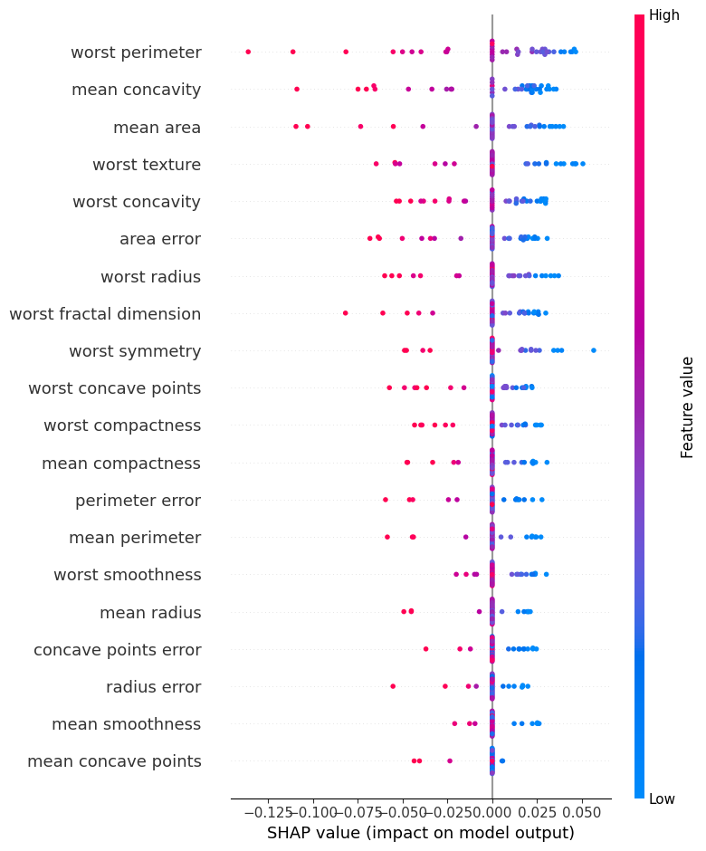

```python
plt.figure()
shap.summary_plot(
    shap_values,
    X_val,
    feature_names=df_X_clean.columns,
    show=True
)
```

********************************************************************************************************************************

Mid-level features—such as area error, worst radius, worst fractal dimension, worst symmetry, worst concave points, and mean compactness—show moderate SHAP impact. Their contributions are more concentrated around zero, yet still display clear directional patterns:

Higher values generally increase malignancy likelihood.

Lower values tend to shift predictions toward the benign class.

These attributes capture structural irregularities and shape distortions, which are relevant but not as dominant as the top features.

Lower-ranked features—including mean radius, worst smoothness, concave points error, mean smoothness, radius error, and mean concave points—exhibit minimal horizontal dispersion. Their SHAP values cluster tightly around zero, suggesting:

The model does not rely heavily on these measurements.

Their discriminative power for this MLP configuration is limited.

They primarily introduce minor adjustments rather than driving the prediction outcome.

Overall, this summary plot reveals that the model’s decision-making is primarily driven by geometric and shape-complexity features of the tumor—particularly those capturing extreme (“worst”) measurements. The dominance of perimeter, concavity, area, and texture is consistent with established diagnostic patterns in breast cancer imaging, indicating that the model’s learned behavior aligns well with clinically meaningful tumor characteristics rather than arbitrary noise.

********************************************************************************************************************************

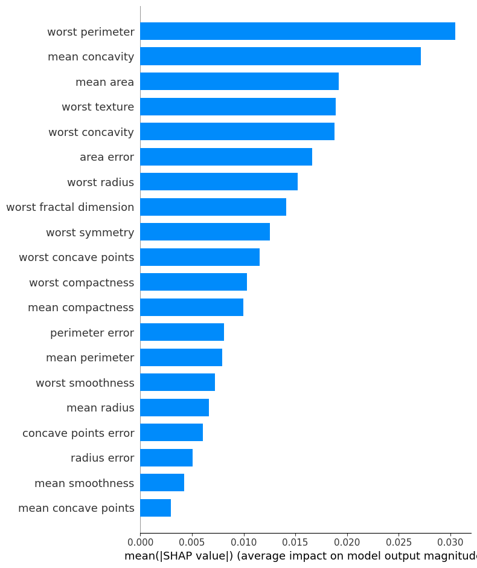

```python
plt.figure()
shap.summary_plot(
    shap_values,
    X_val,
    feature_names=df_X_clean.columns,
    plot_type="bar",
    show=True
)
```

********************************************************************************************************************************

Mid-tier features—including area error, worst radius, worst fractal dimension, worst symmetry, worst concave points, mean compactness, and worst compactness—also play meaningful roles in model predictions, though with smaller average effects. These variables capture structural irregularity, size variability, and geometric complexity, which contribute to the malignancy assessment but are less dominant than the top-ranked concavity and area measures.

At the lower end of the ranking, features such as mean perimeter, mean radius, worst smoothness, concave points error, mean smoothness, radius error, and mean concave points have relatively small average SHAP values. Their limited contribution suggests that the model relies minimally on these measurements when distinguishing between benign and malignant samples. These characteristics likely provide only subtle or redundant information relative to the more impactful geometric and concavity-based attributes.

Overall, the bar plot indicates that the model's global behavior is driven primarily by concavity, area, texture, and radius-related metrics, reflecting a strong alignment with medical understanding of tumor morphology.

********************************************************************************************************************************

```python
shap.initjs()

i = 0
sample_x = X_val[i, :]
sample_shap = shap_values[i, :]

shap.force_plot(
    explainer.expected_value,
    sample_shap,
    sample_x,
    feature_names=df_X_clean.columns
)
```

[output not shown]

********************************************************************************************************************************

********************************************************************************************************************************

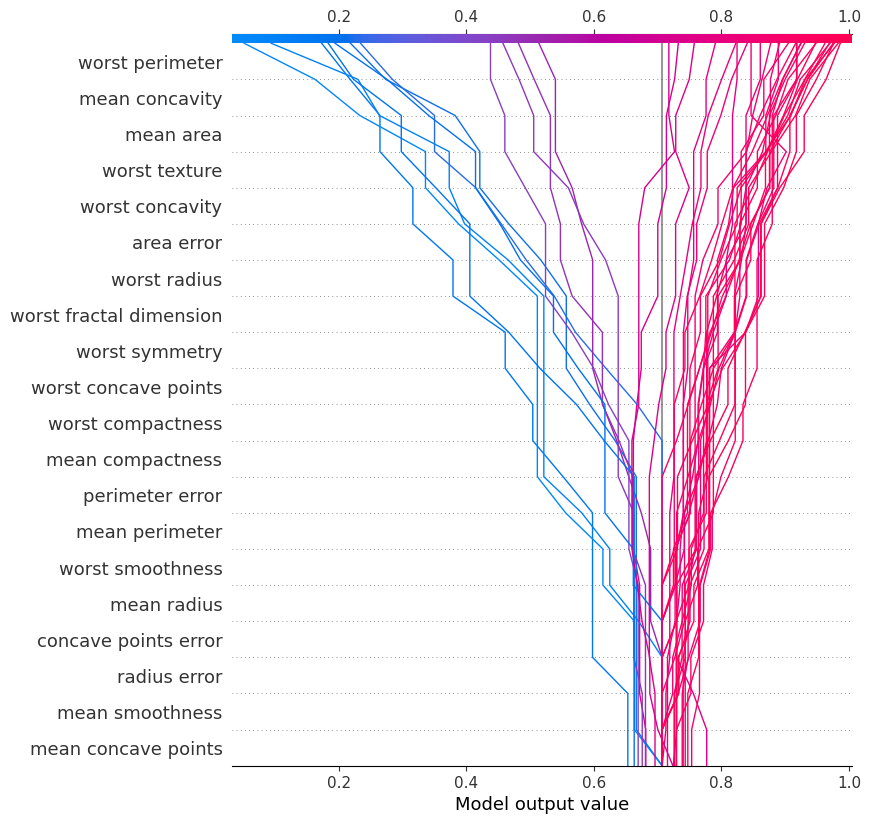

```python
feature_names = list(df_X_clean.columns)

plt.figure()
shap.decision_plot(
    explainer.expected_value,
    shap_values,
    feature_names=feature_names,
    show=True
)
```

Overall, the plot shows that the model consistently relies on a core set of morphology-related attributes to separate malignant and benign cases, leading to stable and interpretable decision pathways across samples.

********************************************************************************************************************************

Overall SHAP Analysis Summary

1. Which features determine the model’s decisions?

Across all SHAP analyses, a clear set of dominant predictors emerges. The model primarily relies on:

mean concavity

mean area

worst texture

worst concavity

area error

worst radius

worst perimeter

worst fractal dimension

worst symmetry

worst concave points

These features represent measurements strongly associated with tumor size, irregularity, and boundary complexity. Their SHAP values exhibit the largest magnitudes and widest distributions, indicating that they exert the strongest influence on the model’s predicted probability of malignancy.

In summary, the classifier’s decisions are predominantly driven by structural and geometric characteristics of the tumor, especially the “worst” (maximum or extreme) measurements.

2. Which features is the Optuna-optimized model most sensitive to?

The Optuna-selected MLP architecture displays heightened sensitivity to a subset of these high-impact variables. The SHAP bar plot and summary plot demonstrate that the model particularly amplifies the influence of:

mean concavity

mean area

worst texture

worst concavity

worst radius / worst perimeter

These variables produce the strongest positive or negative shifts in model output, often dominating both global importance rankings and individual sample explanations. Additionally, in the decision plot, these features consistently generate early and substantial horizontal deviations in prediction trajectories, reflecting their central role in shaping the model's internal decision logic.

Thus, the Optuna model is especially sensitive to features describing concavity patterns, mass area, and perimeter-related measurements.

Common Patterns

The same core feature group (concavity, radius, perimeter, area) consistently appears as the strongest contributor.

High feature values push predictions toward the malignant class, while low values shift predictions toward benign outcomes.

Lower-ranked features (e.g., smoothness error, radius error, symmetry error) exhibit SHAP values clustered near zero, indicating minimal predictive relevance.

Distinct Patterns

Conclusion